# Load data

# Split the train test data

```python
X=df.drop(columns='Target')
Y=df['Target']
```

## We must drop month, day, pdays and previous

```python
X.drop(columns=['month','day','duration','pdays','previous'],inplace=True)
```

```python
X_train,X_test,y_train,y_test=train_test_split(X,Y,test_size=0.30,random_state=1,stratify=Y)
```

```python
for column in [ 'default','housing','loan']:
    X_train[column]=X_train[column].astype('float')
    X_test[column]=X_test[column].astype('float')
```

```python
col_dummy=['job', 'marital','education', 'contact',
        'poutcome']
```

```python
X_train=pd.get_dummies(X_train, columns=col_dummy, drop_first=True)
X_test=pd.get_dummies(X_test, columns=col_dummy, drop_first=True)
```

```python
X_train.info()
```

```
<class 'pandas.core.frame.DataFrame'>
Int64Index: 31574 entries, 31696 to 36691
Data columns (total 27 columns):
 #   Column               Non-Null Count  Dtype
---  ------               --------------  -----
 0   age                  31574 non-null  int64
 1   default              31574 non-null  float64
 2   balance              31574 non-null  int64
 3   housing              31574 non-null  float64
 4   loan                 31574 non-null  float64
 5   campaign             31574 non-null  int64
 6   job_blue-collar      31574 non-null  uint8
 7   job_entrepreneur     31574 non-null  uint8
 8   job_housemaid        31574 non-null  uint8
 9   job_management       31574 non-null  uint8
```

[output cut: 19 more lines]

# Build Model

We need the metric precision to be the highest as the most of the conversion depends on how results of the previous campaigns

```python
def model_performance_classification_sklearn(model, predictors, target):
    """
    Function to compute different metrics to check classification model performance

    model: classifier
    predictors: independent variables
    target: dependent variable
    """


    pred = model.predict(predictors)

    acc = accuracy_score(target, pred)
    recall = recall_score(target, pred)
    precision = precision_score(target, pred)
    f1 = f1_score(target, pred)


    df_perf = pd.DataFrame(
        {
            "Accuracy": acc,
            "Recall": recall,
            "Precision": precision,
            "F1": f1,
        },
        index=[0],
    )

    return df_perf
```

```python
def confusion_matrix_sklearn(model, predictors, target):
    """
    To plot the confusion_matrix with percentages

    model: classifier
    predictors: independent variables
    target: dependent variable
    """
    y_pred = model.predict(predictors)
    cm = confusion_matrix(target, y_pred)
    labels = np.asarray(
        [
            ["{0:0.0f}".format(item) + "\n{0:.2%}".format(item / cm.flatten().sum())]
            for item in cm.flatten()
        ]
    ).reshape(2, 2)

    plt.figure(figsize=(6, 4))
    sns.heatmap(cm, annot=labels, fmt="")
    plt.ylabel("True label")
    plt.xlabel("Predicted label")
```

# Decision Tree

```
Training performance:
    Accuracy    Recall  Precision        F1
0  0.998891  0.990468        1.0  0.995211
Testing performance:
    Accuracy    Recall  Precision        F1
0  0.817691  0.277637   0.247312  0.261598
```

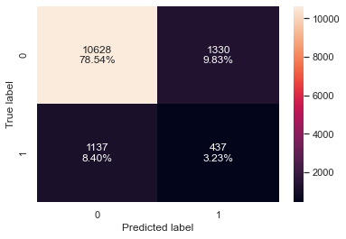

```python
d_tree = DecisionTreeClassifier(random_state=1)
d_tree.fit(X_train,y_train)
d_tree_model_train_perf=model_performance_classification_sklearn(d_tree, X_train,y_train)
print("Training performance:\n", d_tree_model_train_perf)
d_tree_model_test_perf=model_performance_classification_sklearn(d_tree, X_test,y_test)
print("Testing performance:\n", d_tree_model_test_perf)
confusion_matrix_sklearn(d_tree,X_test,y_test)
```

Model is overfitting as training recall and precision are significantly higher

# Cost Complexity Pruining

```python
path = d_tree.cost_complexity_pruning_path(X_train, y_train)

ccp_alphas, impurities = path.ccp_alphas, path.impurities
```

```python
clfs_list = []

for ccp_alpha in ccp_alphas:
    clf = DecisionTreeClassifier(random_state=1, ccp_alpha=ccp_alpha)
    clf.fit(X_train, y_train)
    clfs_list.append(clf)

print("Number of nodes in the last tree is: {} with ccp_alpha: {}".format(clfs_list[-1].tree_.node_count, ccp_alphas[-1]))
```

```
Number of nodes in the last tree is: 1 with ccp_alpha: 0.019262036914617336
```

```python
recall_train=[]
for clf in clfs_list:
    pred_train=clf.predict(X_train)
    values_train=metrics.recall_score(y_train,pred_train)
    recall_train.append(values_train)
```

```python
recall_test=[]
for clf in clfs_list:
    pred_test=clf.predict(X_test)
    values_test=metrics.recall_score(y_test,pred_test)
    recall_test.append(values_test)
```

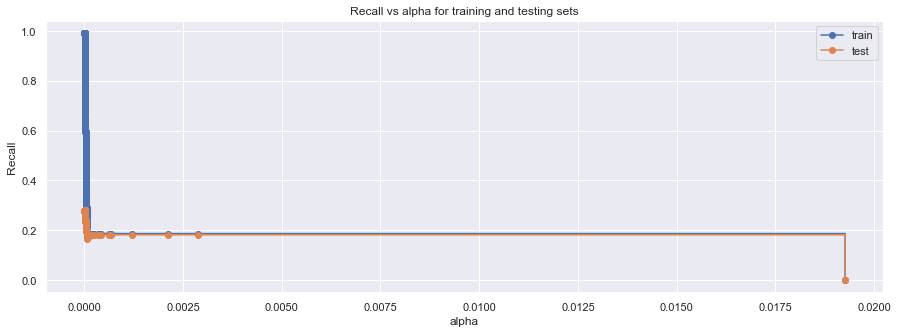

```python
fig, ax = plt.subplots(figsize=(15,5))
ax.set_xlabel("alpha")
ax.set_ylabel("Recall")
ax.set_title("Recall vs alpha for training and testing sets")
ax.plot(ccp_alphas, recall_train, marker='o', label="train",
        drawstyle="steps-post")
ax.plot(ccp_alphas, recall_test, marker='o', label="test",
        drawstyle="steps-post")
ax.legend()
plt.show()
```

```
Training performance:
    Accuracy    Recall  Precision        F1
0  0.998828  0.992102   0.997809  0.994947
Testing performance:
    Accuracy    Recall  Precision       F1
0  0.817765  0.278907   0.248023  0.26256
```

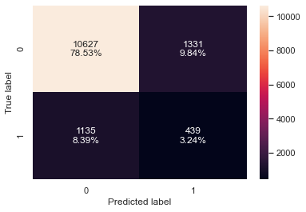

```python
index_best_pruned_model = np.argmax(recall_test)
pruned_dtree_model = clfs_list[index_best_pruned_model]
pruned_dtree_model_train_perf=model_performance_classification_sklearn(pruned_dtree_model, X_train,y_train)
print("Training performance:\n", pruned_dtree_model_train_perf)
pruned_dtree_model_test_perf=model_performance_classification_sklearn(pruned_dtree_model, X_test,y_test)
print("Testing performance:\n", pruned_dtree_model_test_perf)
confusion_matrix_sklearn(pruned_dtree_model,X_test,y_test)
```

The model still hasnt improved as it is overfitting on the training set

# Hyperparameter Tuning

```python
dtree_estimator = DecisionTreeClassifier(class_weight={0:0.12,1:0.88},random_state=1)
parameters = {'max_depth': np.arange(2,30),
              'min_samples_leaf': [1, 2, 5, 7, 10],
              'max_leaf_nodes' : [2, 3, 5, 10,15],
              'min_impurity_decrease': [0.0001,0.001,0.01,0.1]
             }
scorer = metrics.make_scorer(metrics.recall_score)
grid_obj = GridSearchCV(dtree_estimator, parameters, scoring=scorer,n_jobs=-1)
grid_obj = grid_obj.fit(X_train, y_train)
dtree_estimator = grid_obj.best_estimator_
dtree_estimator.fit(X_train, y_train)
```

```
DecisionTreeClassifier(class_weight={0: 0.12, 1: 0.88}, max_depth=2,
                       max_leaf_nodes=3, min_impurity_decrease=0.0001,
                       random_state=1)
```

```
Training performance:
    Accuracy    Recall  Precision        F1
0  0.381738  0.895969   0.146685  0.252098
Testing performance:
    Accuracy    Recall  Precision        F1
0  0.380358  0.907878   0.147792  0.254203
```

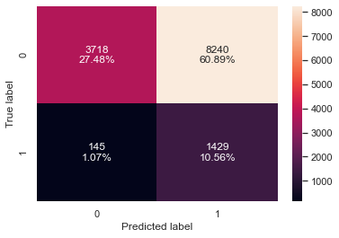

```python
dtree_estimator_model_train_perf=model_performance_classification_sklearn(dtree_estimator, X_train,y_train)
print("Training performance:\n", dtree_estimator_model_train_perf)
dtree_estimator_model_test_perf=model_performance_classification_sklearn(dtree_estimator, X_test,y_test)
print("Testing performance:\n", dtree_estimator_model_test_perf)
confusion_matrix_sklearn(dtree_estimator,X_test,y_test)
```

The model is not overfitting in the data

# Random Forest Classifier

```
Training performance:
    Accuracy    Recall  Precision        F1
0   0.99886  0.993736    0.99645  0.995091
Testing performance:
    Accuracy    Recall  Precision        F1
0  0.883905  0.196315   0.502439  0.282321
```

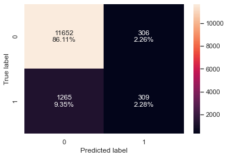

```python
rf_estimator = RandomForestClassifier(random_state=1)
rf_estimator.fit(X_train,y_train)
rf_estimator_model_train_perf=model_performance_classification_sklearn(rf_estimator, X_train,y_train)
print("Training performance:\n",rf_estimator_model_train_perf)
rf_estimator_model_test_perf=model_performance_classification_sklearn(rf_estimator, X_test,y_test)
print("Testing performance:\n",rf_estimator_model_test_perf)
confusion_matrix_sklearn(rf_estimator,X_test,y_test)
```

This model performs better for precision and poor on recall.

We also see that the model is overfitting on training set

# Hyperparameter Tuning

```python
rf_tuned = RandomForestClassifier(class_weight={0:0.12,1:0.88},random_state=1,oob_score=True,bootstrap=True)
parameters = {
                'max_depth': list(np.arange(5,30,5)) + [None],
                'max_features': ['sqrt','log2',None],
                'min_samples_leaf': np.arange(1,15,5),
                'min_samples_split': np.arange(2, 20, 5),
                'n_estimators': np.arange(10,110,10)}
grid_obj = GridSearchCV(rf_tuned, parameters, scoring='recall',cv=5,n_jobs=-1)
grid_obj = grid_obj.fit(X_train, y_train)
rf_tuned = grid_obj.best_estimator_
rf_tuned.fit(X_train, y_train)
```

```
RandomForestClassifier(class_weight={0: 0.12, 1: 0.88}, max_depth=5,
                       max_features='sqrt', min_samples_leaf=11,
                       n_estimators=20, oob_score=True, random_state=1)
```

```
Training performance:
    Accuracy  Recall  Precision        F1
0  0.738456   0.625   0.250109  0.357254
Testing performance:
    Accuracy  Recall  Precision        F1
0  0.732634  0.6277   0.245771  0.353236
```

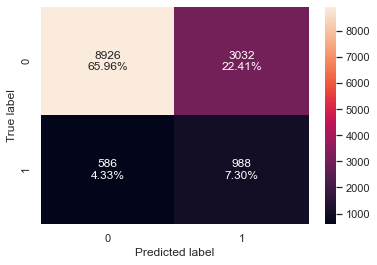

```python
rf_tuned_model_train_perf=model_performance_classification_sklearn(rf_tuned, X_train,y_train)
print("Training performance:\n",rf_tuned_model_train_perf)
rf_tuned_model_test_perf=model_performance_classification_sklearn(rf_tuned, X_test,y_test)
print("Testing performance:\n",rf_tuned_model_test_perf)
confusion_matrix_sklearn(rf_tuned,X_test,y_test)
```

The model is not overfitting as much and the metrics are better

# Bagging Classifier

```
Training performance:
    Accuracy    Recall  Precision        F1
0  0.981535  0.848856   0.991097  0.914479
Testing performance:
    Accuracy    Recall  Precision        F1
0  0.881614  0.186785   0.477273  0.268493
```

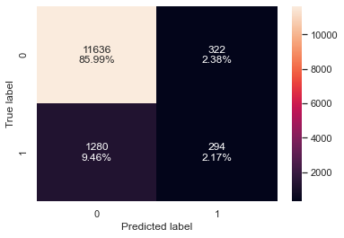

```python
bagging_classifier = BaggingClassifier(random_state=1)
bagging_classifier.fit(X_train,y_train)
bagging_classifier_model_train_perf=model_performance_classification_sklearn(bagging_classifier, X_train,y_train)
print("Training performance:\n",bagging_classifier_model_train_perf)
bagging_classifier_model_test_perf=model_performance_classification_sklearn(bagging_classifier, X_test,y_test)
print("Testing performance:\n",bagging_classifier_model_test_perf)
confusion_matrix_sklearn(bagging_classifier,X_test,y_test)
```

The model is still overfitting and the precision is good in testing

# Hyperparameter Tuning

```python
bagging_estimator_tuned = BaggingClassifier(random_state=1)
parameters = {'max_samples': [0.7,0.8,0.9,1],
              'max_features': [0.7,0.8,0.9,1],
              'n_estimators' : [10,20,30,40,50],
             }
acc_scorer = metrics.make_scorer(metrics.recall_score)
grid_obj = GridSearchCV(bagging_estimator_tuned, parameters, scoring=acc_scorer,cv=5)
grid_obj = grid_obj.fit(X_train, y_train)
bagging_estimator_tuned = grid_obj.best_estimator_
bagging_estimator_tuned.fit(X_train, y_train)
```

```
BaggingClassifier(max_features=0.9, max_samples=0.9, n_estimators=50,
                  random_state=1)
```

```
Training performance:
    Accuracy    Recall  Precision        F1
0  0.993064  0.942538   0.997694  0.969332
Testing performance:
    Accuracy    Recall  Precision        F1
0  0.888191  0.175349   0.562118  0.267312
```

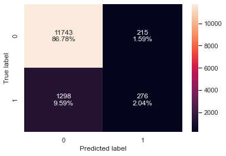

```python
bagging_estimator_tuned_model_train_perf=model_performance_classification_sklearn(bagging_estimator_tuned, X_train,y_train)
print("Training performance:\n",bagging_estimator_tuned_model_train_perf)
bagging_estimator_tuned_model_test_perf=model_performance_classification_sklearn(bagging_estimator_tuned, X_test,y_test)
print("Testing performance:\n",bagging_estimator_tuned_model_test_perf)
confusion_matrix_sklearn(bagging_estimator_tuned,X_test,y_test)
```

The precision metric is performing better on the test set

# AdaBoost Classifier

```
Training performance:
    Accuracy    Recall  Precision        F1
0  0.892633  0.163399   0.653595  0.261438
Testing performance:
    Accuracy    Recall  Precision       F1
0  0.894251  0.165184   0.689655  0.26653
```

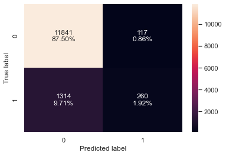

```python
ab_classifier = AdaBoostClassifier(random_state=1)
ab_classifier.fit(X_train,y_train)
ab_classifier_model_train_perf=model_performance_classification_sklearn(ab_classifier, X_train,y_train)
print("Training performance:\n",ab_classifier_model_train_perf)
ab_classifier_model_test_perf=model_performance_classification_sklearn(ab_classifier, X_test,y_test)
print("Testing performance:\n",ab_classifier_model_test_perf)
confusion_matrix_sklearn(ab_classifier,X_test,y_test)
```

The model is not overfitting and is performing well in the precision metric on both sets

# Hyperparameter Tuning

```python
abc_tuned = AdaBoostClassifier(random_state=1)
parameters = {
    "base_estimator":[DecisionTreeClassifier(max_depth=1),DecisionTreeClassifier(max_depth=2),
                      DecisionTreeClassifier(max_depth=3)],
    "n_estimators": np.arange(10,110,10),
    "learning_rate":np.arange(0.1,2,0.1)
}
acc_scorer = metrics.make_scorer(metrics.recall_score)
grid_obj = GridSearchCV(abc_tuned, parameters, scoring=acc_scorer,cv=5)
grid_obj = grid_obj.fit(X_train, y_train)
abc_tuned = grid_obj.best_estimator_
abc_tuned.fit(X_train, y_train)
```

```
AdaBoostClassifier(base_estimator=DecisionTreeClassifier(max_depth=3),
                   learning_rate=1.5000000000000002, n_estimators=90,
                   random_state=1)
```

```
Training performance:
    Accuracy    Recall  Precision        F1
0    0.8958  0.253813    0.62888  0.361661
Testing performance:
    Accuracy    Recall  Precision        F1
0  0.883388  0.189962   0.496678  0.274816
```

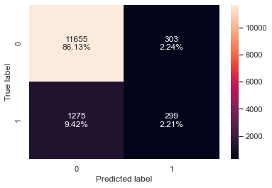

```python
abc_tuned_model_train_perf=model_performance_classification_sklearn(abc_tuned, X_train,y_train)
print("Training performance:\n",abc_tuned_model_train_perf)
abc_tuned_model_test_perf=model_performance_classification_sklearn(abc_tuned, X_test,y_test)
print("Testing performance:\n",abc_tuned_model_test_perf)
confusion_matrix_sklearn(abc_tuned,X_test,y_test)
```

The model is not overfitting but the precision metrics perform differently on train and test set

# Gradient Boosting Classifier

```
Training performance:
    Accuracy    Recall  Precision       F1
0  0.895009  0.177015    0.68929  0.28169
Testing performance:
    Accuracy    Recall  Precision        F1
0  0.894029  0.169632   0.677665  0.271341
```

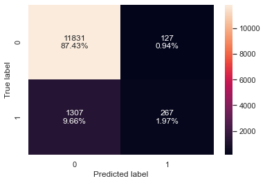

```python
gb_classifier = GradientBoostingClassifier(random_state=1)
gb_classifier.fit(X_train,y_train)
gb_classifier_model_train_perf=model_performance_classification_sklearn(gb_classifier, X_train,y_train)
print("Training performance:\n",gb_classifier_model_train_perf)
gb_classifier_model_test_perf=model_performance_classification_sklearn(gb_classifier, X_test,y_test)
print("Testing performance:\n",gb_classifier_model_test_perf)
confusion_matrix_sklearn(gb_classifier,X_test,y_test)
```

# Hyperparameter Tuning

```python
gbc_tuned = GradientBoostingClassifier(init=AdaBoostClassifier(random_state=1),random_state=1)
parameters = {
    "n_estimators": [100,150,200,250],
    "subsample":[0.8,0.9,1],
    "max_features":[0.7,0.8,0.9,1]
}
acc_scorer = metrics.make_scorer(metrics.recall_score)
grid_obj = GridSearchCV(gbc_tuned, parameters, scoring=acc_scorer,cv=5)
grid_obj = grid_obj.fit(X_train, y_train)
gbc_tuned = grid_obj.best_estimator_
gbc_tuned.fit(X_train, y_train)
```

```
GradientBoostingClassifier(init=AdaBoostClassifier(random_state=1),
                           max_features=0.8, n_estimators=250, random_state=1,
                           subsample=1)
```

```
Training performance:
    Accuracy    Recall  Precision        F1
0  0.897257  0.191176   0.719262  0.302065
Testing performance:
    Accuracy    Recall  Precision        F1
0  0.893659  0.175349   0.661871  0.277248
```

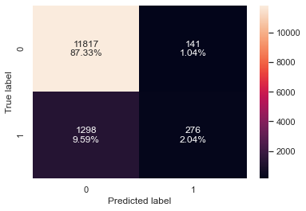

```python
#Calculating different metrics
gbc_tuned_model_train_perf=model_performance_classification_sklearn(gbc_tuned, X_train,y_train)
print("Training performance:\n",gbc_tuned_model_train_perf)
gbc_tuned_model_test_perf=model_performance_classification_sklearn(gbc_tuned, X_test,y_test)
print("Testing performance:\n",gbc_tuned_model_test_perf)

#Creating confusion matrix
confusion_matrix_sklearn(gbc_tuned,X_test,y_test)
```

The model is not overfitting, and the model has good precision

# Comparing all models

```python
models_train_comp_df = pd.concat(
    [d_tree_model_train_perf.T,pruned_dtree_model_train_perf.T, dtree_estimator_model_train_perf.T, rf_estimator_model_train_perf.T,
    rf_tuned_model_train_perf.T,bagging_classifier_model_train_perf.T,bagging_estimator_tuned_model_train_perf.T,ab_classifier_model_train_perf.T,
     abc_tuned_model_train_perf.T,gb_classifier_model_train_perf.T,gbc_tuned_model_train_perf.T],
    axis=1,
)
models_train_comp_df.columns = [
    "Decision Tree",
    "Prunned Decision Tree",
    "Decision Tree Estimator",
    "Random Forest Estimator",
    "Random Forest Tuned",
    "Bagging Classifier",
    "Bagging Estimator Tuned",
    "Adaboost Classifier",
    "Adaboost Classifier Tuned",
     "Gradient Boost Classifier",
    "Gradient Boost Classifier Tuned"]
models_train_comp_df
```

|  | Decision Tree | Prunned Decision Tree | Decision Tree Estimator | Random Forest Estimator | Random Forest Tuned | Bagging Classifier | Bagging Estimator Tuned | Adaboost Classifier | Adaboost Classifier Tuned | Gradient Boost Classifier | Gradient Boost Classifier Tuned |
| --- | --- | --- | --- | --- | --- | --- | --- | --- | --- | --- | --- |
| Accuracy | 0.998891 | 0.998828 | 0.381738 | 0.998860 | 0.738456 | 0.981535 | 0.993064 | 0.892633 | 0.895800 | 0.895009 | 0.897257 |
| Recall | 0.990468 | 0.992102 | 0.895969 | 0.993736 | 0.625000 | 0.848856 | 0.942538 | 0.163399 | 0.253813 | 0.177015 | 0.191176 |
| Precision | 1.000000 | 0.997809 | 0.146685 | 0.996450 | 0.250109 | 0.991097 | 0.997694 | 0.653595 | 0.628880 | 0.689290 | 0.719262 |
| F1 | 0.995211 | 0.994947 | 0.252098 | 0.995091 | 0.357254 | 0.914479 | 0.969332 | 0.261438 | 0.361661 | 0.281690 | 0.302065 |

```python
# Testing performance comparison

models_test_comp_df = pd.concat(
    [d_tree_model_test_perf.T,pruned_dtree_model_test_perf.T, dtree_estimator_model_test_perf.T, rf_estimator_model_test_perf.T,
    rf_tuned_model_test_perf.T,bagging_classifier_model_test_perf.T,bagging_estimator_tuned_model_test_perf.T,ab_classifier_model_test_perf.T,
     abc_tuned_model_test_perf.T,gb_classifier_model_test_perf.T,gbc_tuned_model_test_perf.T],
    axis=1,
)
models_test_comp_df.columns = [
    "Decision Tree",
    "Prunned Decision Tree",
    "Decision Tree Estimator",
    "Random Forest Estimator",
    "Random Forest Tuned",
    "Bagging Classifier",
    "Bagging Estimator Tuned",
    "Adaboost Classifier",
    "Adaboost Classifier Tuned",
     "Gradient Boost Classifier",
    "Gradient Boost Classifier Tuned"]
print("Testing performance comparison:")
models_test_comp_df
```

```
Testing performance comparison:
```

|  | Decision Tree | Prunned Decision Tree | Decision Tree Estimator | Random Forest Estimator | Random Forest Tuned | Bagging Classifier | Bagging Estimator Tuned | Adaboost Classifier | Adaboost Classifier Tuned | Gradient Boost Classifier | Gradient Boost Classifier Tuned |
| --- | --- | --- | --- | --- | --- | --- | --- | --- | --- | --- | --- |
| Accuracy | 0.817691 | 0.817765 | 0.380358 | 0.883905 | 0.732634 | 0.881614 | 0.888191 | 0.894251 | 0.883388 | 0.894029 | 0.893659 |
| Recall | 0.277637 | 0.278907 | 0.907878 | 0.196315 | 0.627700 | 0.186785 | 0.175349 | 0.165184 | 0.189962 | 0.169632 | 0.175349 |
| Precision | 0.247312 | 0.248023 | 0.147792 | 0.502439 | 0.245771 | 0.477273 | 0.562118 | 0.689655 | 0.496678 | 0.677665 | 0.661871 |
| F1 | 0.261598 | 0.262560 | 0.254203 | 0.282321 | 0.353236 | 0.268493 | 0.267312 | 0.266530 | 0.274816 | 0.271341 | 0.277248 |

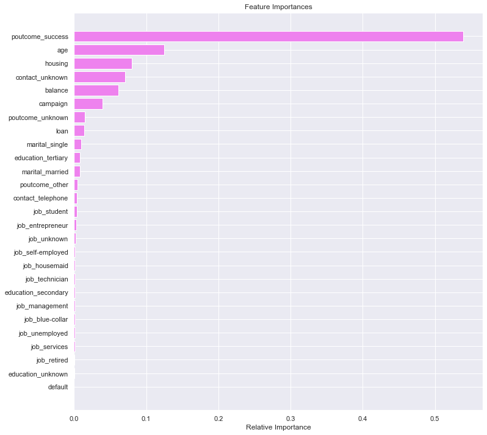

```python
feature_names = X_train.columns
importances = gb_classifier.feature_importances_
indices = np.argsort(importances)

plt.figure(figsize=(12,12))
plt.title('Feature Importances')
plt.barh(range(len(indices)), importances[indices], color='violet', align='center')
plt.yticks(range(len(indices)), [feature_names[i] for i in indices])
plt.xlabel('Relative Importance')
plt.show()
```

Previous outcome plays a big factor in success, followed by age and the housing loan

# Reccomendations

While conducting the campaign, the time and day of call and other external facrtors should be accounted as well